# restart ther proj

```python
import numpy as np
import seaborn as sns
import pandas as pd
import matplotlib.pyplot as plt
```

```python
df =pd.read_csv('Car_sales.csv')
```

```python
df
```

|  | Manufacturer | Model | Sales_in_thousands | __year_resale_value | Vehicle_type | Price_in_thousands | Engine_size | Horsepower | Wheelbase | Width | Length | Curb_weight | Fuel_capacity | Fuel_efficiency | Latest_Launch | Power_perf_factor |
| --- | --- | --- | --- | --- | --- | --- | --- | --- | --- | --- | --- | --- | --- | --- | --- | --- |
| 0 | Acura | Integra | 16.919 | 16.360 | Passenger | 21.50 | 1.8 | 140.0 | 101.2 | 67.3 | 172.4 | 2.639 | 13.2 | 28.0 | 2/2/2012 | 58.280150 |
| 1 | Acura | TL | 39.384 | 19.875 | Passenger | 28.40 | 3.2 | 225.0 | 108.1 | 70.3 | 192.9 | 3.517 | 17.2 | 25.0 | 6/3/2011 | 91.370778 |
| 2 | Acura | CL | 14.114 | 18.225 | Passenger | NaN | 3.2 | 225.0 | 106.9 | 70.6 | 192.0 | 3.470 | 17.2 | 26.0 | 1/4/2012 | NaN |
| 3 | Acura | RL | 8.588 | 29.725 | Passenger | 42.00 | 3.5 | 210.0 | 114.6 | 71.4 | 196.6 | 3.850 | 18.0 | 22.0 | 3/10/2011 | 91.389779 |
| 4 | Audi | A4 | 20.397 | 22.255 | Passenger | 23.99 | 1.8 | 150.0 | 102.6 | 68.2 | 178.0 | 2.998 | 16.4 | 27.0 | 10/8/2011 | 62.777639 |
| ... | ... | ... | ... | ... | ... | ... | ... | ... | ... | ... | ... | ... | ... | ... | ... | ... |
| 152 | Volvo | V40 | 3.545 | NaN | Passenger | 24.40 | 1.9 | 160.0 | 100.5 | 67.6 | 176.6 | 3.042 | 15.8 | 25.0 | 9/21/2011 | 66.498812 |
| 153 | Volvo | S70 | 15.245 | NaN | Passenger | 27.50 | 2.4 | 168.0 | 104.9 | 69.3 | 185.9 | 3.208 | 17.9 | 25.0 | 11/24/2012 | 70.654495 |
| 154 | Volvo | V70 | 17.531 | NaN | Passenger | 28.80 | 2.4 | 168.0 | 104.9 | 69.3 | 186.2 | 3.259 | 17.9 | 25.0 | 6/25/2011 | 71.155978 |
| 155 | Volvo | C70 | 3.493 | NaN | Passenger | 45.50 | 2.3 | 236.0 | 104.9 | 71.5 | 185.7 | 3.601 | 18.5 | 23.0 | 4/26/2011 | 101.623357 |
| 156 | Volvo | S80 | 18.969 | NaN | Passenger | 36.00 | 2.9 | 201.0 | 109.9 | 72.1 | 189.8 | 3.600 | 21.1 | 24.0 | 11/14/2011 | 85.735655 |

157 rows × 16 columns

## Business problem understanding

- -A car dealership chain wants to increase its monthly sales and improve profitability. Management wants to understand:

-Which car models sell the most and least?

-How price, engine size, mileage, and brand affect sales.

-What discounts or marketing strategy will increase sales?

## Data understanding

```python
df.shape
#(157) rows and (16)columns in dataset
```

```
(157, 16)
```

```python
df.info()
# 12/16 columns are continues variable
# 3  columns are discreate categorical
# and one column are discret count
```

```
<class 'pandas.core.frame.DataFrame'>
RangeIndex: 157 entries, 0 to 156
Data columns (total 16 columns):
 #   Column               Non-Null Count  Dtype
---  ------               --------------  -----
 0   Manufacturer         157 non-null    object
 1   Model                157 non-null    object
 2   Sales_in_thousands   157 non-null    float64
 3   __year_resale_value  121 non-null    float64
 4   Vehicle_type         157 non-null    object
 5   Price_in_thousands   155 non-null    float64
 6   Engine_size          156 non-null    float64
 7   Horsepower           156 non-null    float64
 8   Wheelbase            156 non-null    float64
 9   Width                156 non-null    float64
 10  Length               156 non-null    float64
 11  Curb_weight          155 non-null    float64
 12  Fuel_capacity        156 non-null    float64
 13  Fuel_efficiency      154 non-null    float64
 14  Latest_Launch        157 non-null    object
 15  Power_perf_factor    155 non-null    float64
dtypes: float64(12), object(4)
memory usage: 19.8+ KB
```

```python
# yearly sales column is wrong wrote
```

```python
df.describe()
```

|  | Sales_in_thousands | __year_resale_value | Price_in_thousands | Engine_size | Horsepower | Wheelbase | Width | Length | Curb_weight | Fuel_capacity | Fuel_efficiency | Power_perf_factor |
| --- | --- | --- | --- | --- | --- | --- | --- | --- | --- | --- | --- | --- |
| count | 157.000000 | 121.000000 | 155.000000 | 156.000000 | 156.000000 | 156.000000 | 156.000000 | 156.000000 | 155.000000 | 156.000000 | 154.000000 | 155.000000 |
| mean | 52.998076 | 18.072975 | 27.390755 | 3.060897 | 185.948718 | 107.487179 | 71.150000 | 187.343590 | 3.378026 | 17.951923 | 23.844156 | 77.043591 |
| std | 68.029422 | 11.453384 | 14.351653 | 1.044653 | 56.700321 | 7.641303 | 3.451872 | 13.431754 | 0.630502 | 3.887921 | 4.282706 | 25.142664 |
| min | 0.110000 | 5.160000 | 9.235000 | 1.000000 | 55.000000 | 92.600000 | 62.600000 | 149.400000 | 1.895000 | 10.300000 | 15.000000 | 23.276272 |
| 25% | 14.114000 | 11.260000 | 18.017500 | 2.300000 | 149.500000 | 103.000000 | 68.400000 | 177.575000 | 2.971000 | 15.800000 | 21.000000 | 60.407707 |
| 50% | 29.450000 | 14.180000 | 22.799000 | 3.000000 | 177.500000 | 107.000000 | 70.550000 | 187.900000 | 3.342000 | 17.200000 | 24.000000 | 72.030917 |
| 75% | 67.956000 | 19.875000 | 31.947500 | 3.575000 | 215.000000 | 112.200000 | 73.425000 | 196.125000 | 3.799500 | 19.575000 | 26.000000 | 89.414878 |
| max | 540.561000 | 67.550000 | 85.500000 | 8.000000 | 450.000000 | 138.700000 | 79.900000 | 224.500000 | 5.572000 | 32.000000 | 45.000000 | 188.144323 |

```python
df.dtypes
```

```
Manufacturer            object
Model                   object
Sales_in_thousands     float64
__year_resale_value    float64
Vehicle_type            object
Price_in_thousands     float64
Engine_size            float64
Horsepower             float64
Wheelbase              float64
Width                  float64
Length                 float64
Curb_weight            float64
Fuel_capacity          float64
Fuel_efficiency        float64
Latest_Launch           object
Power_perf_factor      float64
dtype: object
```

```python
## all column correct datatype
```

```python
# chaenging column name in lower case
df.columns = df.columns.str.lower()
```

```python
descrete=[df['manufacturer'],df['model'],df['vehicle_type']]
```

```python
df['manufacturer'].unique()
```

```
array(['Acura', 'Audi', 'BMW', 'Buick', 'Cadillac', 'Chevrolet',
       'Chrysler', 'Dodge', 'Ford', 'Honda', 'Hyundai', 'Infiniti',
       'Jaguar', 'Jeep', 'Lexus', 'Lincoln', 'Mitsubishi', 'Mercury',
       'Mercedes-B', 'Nissan', 'Oldsmobile', 'Plymouth', 'Pontiac',
       'Porsche', 'Saab', 'Saturn', 'Subaru', 'Toyota', 'Volkswagen',
       'Volvo'], dtype=object)
```

```python
len(df['manufacturer'].unique())
```

```
30
```

```python
# in column manufacturer has 30 unique category
```

```python
df['model'].unique()
```

```
array(['Integra', 'TL', 'CL', 'RL', 'A4', 'A6', 'A8', '323i', '328i',
       '528i', 'Century', 'Regal', 'Park Avenue', 'LeSabre', 'DeVille',
       'Seville', 'Eldorado', 'Catera', 'Escalade', 'Cavalier', 'Malibu',
       'Lumina', 'Monte Carlo', 'Camaro', 'Corvette', 'Prizm', 'Metro',
       'Impala', 'Sebring Coupe', 'Sebring Conv.', 'Concorde', 'Cirrus',
       'LHS', 'Town & Country', '300M', 'Neon', 'Avenger', 'Stratus',
       'Intrepid', 'Viper', 'Ram Pickup', 'Ram Wagon', 'Ram Van',
       'Dakota', 'Durango', 'Caravan', 'Escort', 'Mustang', 'Contour',
       'Taurus', 'Focus', 'Crown Victoria', 'Explorer', 'Windstar',
       'Expedition', 'Ranger', 'F-Series', 'Civic', 'Accord', 'CR-V',
       'Passport', 'Odyssey', 'Accent', 'Elantra', 'Sonata', 'I30',
       'S-Type', 'Wrangler', 'Cherokee', 'Grand Cherokee', 'ES300',
       'GS300', 'GS400', 'LS400', 'LX470', 'RX300', 'Continental',
       'Town car', 'Navigator', 'Mirage', 'Eclipse', 'Galant', 'Diamante',
       '3000GT', 'Montero', 'Montero Sport', 'Mystique', 'Cougar',
       'Sable', 'Grand Marquis', 'Mountaineer', 'Villager', 'C-Class',
       'E-Class', 'S-Class', 'SL-Class', 'SLK', 'SLK230', 'CLK Coupe',
       'CL500', 'M-Class', 'Sentra', 'Altima', 'Maxima', 'Quest',
       'Pathfinder', 'Xterra', 'Frontier', 'Cutlass', 'Intrigue', 'Alero',
       'Aurora', 'Bravada', 'Silhouette', 'Breeze', 'Voyager', 'Prowler',
       'Sunfire', 'Grand Am', 'Firebird', 'Grand Prix', 'Bonneville',
       'Montana', 'Boxter', 'Carrera Coupe', 'Carrera Cabrio', '5-Sep',
       '3-Sep', 'SL', 'SC', 'SW', 'LW', 'LS', 'Outback', 'Forester',
       'Corolla', 'Camry', 'Avalon', 'Celica', 'Tacoma', 'Sienna', 'RAV4',
       '4Runner', 'Land Cruiser', 'Golf', 'Jetta', 'Passat', 'Cabrio',
       'GTI', 'Beetle', 'S40', 'V40', 'S70', 'V70', 'C70', 'S80'],
      dtype=object)
```

```python
len(df['model'].unique())
```

```
156
```

```python
# 156 different models in model
```

```python
df['vehicle_type'].unique()
```

```
array(['Passenger', 'Car'], dtype=object)
```

```python
# two types of vechile
```

```python
df.describe()
```

|  | sales_in_thousands | __year_resale_value | price_in_thousands | engine_size | horsepower | wheelbase | width | length | curb_weight | fuel_capacity | fuel_efficiency | power_perf_factor |
| --- | --- | --- | --- | --- | --- | --- | --- | --- | --- | --- | --- | --- |
| count | 157.000000 | 121.000000 | 155.000000 | 156.000000 | 156.000000 | 156.000000 | 156.000000 | 156.000000 | 155.000000 | 156.000000 | 154.000000 | 155.000000 |
| mean | 52.998076 | 18.072975 | 27.390755 | 3.060897 | 185.948718 | 107.487179 | 71.150000 | 187.343590 | 3.378026 | 17.951923 | 23.844156 | 77.043591 |
| std | 68.029422 | 11.453384 | 14.351653 | 1.044653 | 56.700321 | 7.641303 | 3.451872 | 13.431754 | 0.630502 | 3.887921 | 4.282706 | 25.142664 |
| min | 0.110000 | 5.160000 | 9.235000 | 1.000000 | 55.000000 | 92.600000 | 62.600000 | 149.400000 | 1.895000 | 10.300000 | 15.000000 | 23.276272 |
| 25% | 14.114000 | 11.260000 | 18.017500 | 2.300000 | 149.500000 | 103.000000 | 68.400000 | 177.575000 | 2.971000 | 15.800000 | 21.000000 | 60.407707 |
| 50% | 29.450000 | 14.180000 | 22.799000 | 3.000000 | 177.500000 | 107.000000 | 70.550000 | 187.900000 | 3.342000 | 17.200000 | 24.000000 | 72.030917 |
| 75% | 67.956000 | 19.875000 | 31.947500 | 3.575000 | 215.000000 | 112.200000 | 73.425000 | 196.125000 | 3.799500 | 19.575000 | 26.000000 | 89.414878 |
| max | 540.561000 | 67.550000 | 85.500000 | 8.000000 | 450.000000 | 138.700000 | 79.900000 | 224.500000 | 5.572000 | 32.000000 | 45.000000 | 188.144323 |

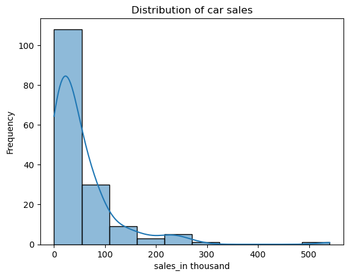

```python
sns.histplot(df['sales_in_thousands'], bins=10, kde = True)
plt.title('Distribution of car sales')
plt.ylabel('Frequency')
plt.xlabel('sales_in thousand')
plt.show()
```

## observation

- most cars sales in range of (10,100)
- less cars sales up to 300
- Data is right skewd

```python
df['sales_in_thousands'].skew()
```

```
np.float64(3.408518366470572)
```

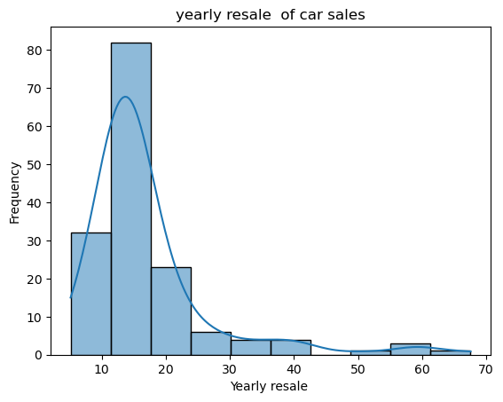

```python
sns.histplot(df['year_resale'], bins=10, kde = True)
plt.title('yearly resale  of car sales')
plt.ylabel('Frequency')
plt.xlabel('Yearly resale ')
plt.show()
```

## Observation

- most cars resale value is between (10,30)
- this data is right skewed

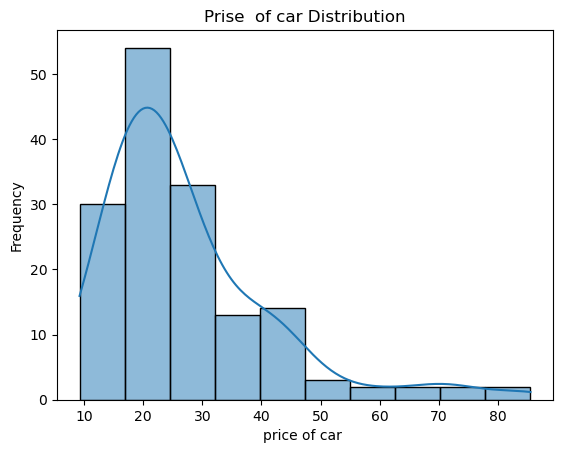

```python
sns.histplot(df['price_in_thousands'], bins=10, kde = True)
plt.title('Prise  of car Distribution')
plt.ylabel('Frequency')
plt.xlabel('price of car ')
plt.show()
```

## Ovservation

- which car has price between(10,50) thousand That has more sales
- this data is also right skewed

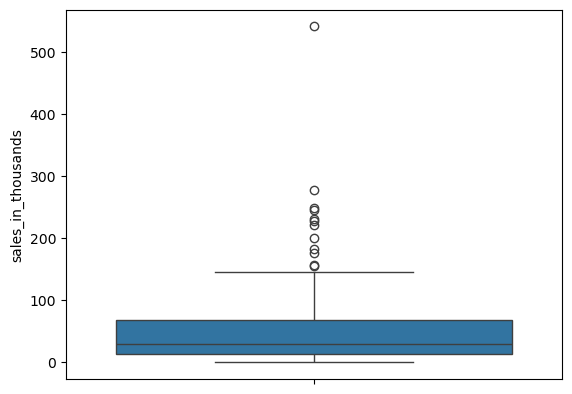

```python
sns.boxplot(df['sales_in_thousands'])
plt.show()
```

```python
# extracging outliers
Q1 = df['sales_in_thousands'].quantile(0.25)
Q3 = df['sales_in_thousands'].quantile(0.75)
iqr = Q3-Q1
```

```python
lower_limit= Q1-1.5*iqr
upper_limit = Q3+1.5*iqr
```

```python
df[(df['sales_in_thousands'] > upper_limit) | (df['sales_in_thousands'] <= lower_limit)]
```

|  | manufacturer | model | sales_in_thousands | __year_resale_value | vehicle_type | price_in_thousands | engine_size | horsepower | wheelbase | width | length | curb_weight | fuel_capacity | fuel_efficiency | latest_launch | power_perf_factor |
| --- | --- | --- | --- | --- | --- | --- | --- | --- | --- | --- | --- | --- | --- | --- | --- | --- |
| 40 | Dodge | Ram Pickup | 227.061 | 15.060 | Car | 19.460 | 5.2 | 230.0 | 138.7 | 79.3 | 224.2 | 4.470 | 26.0 | 17.0 | 3/6/2012 | 90.211700 |
| 45 | Dodge | Caravan | 181.749 | 12.025 | Car | 19.565 | 2.4 | 150.0 | 113.3 | 76.8 | 186.3 | 3.533 | 20.0 | 24.0 | 9/1/2011 | 61.227000 |
| 49 | Ford | Taurus | 245.815 | 10.055 | Passenger | 17.885 | 3.0 | 155.0 | 108.5 | 73.0 | 197.6 | 3.368 | 16.0 | 24.0 | 12/20/2011 | 62.503740 |
| 50 | Ford | Focus | 175.670 | NaN | Passenger | 12.315 | 2.0 | 107.0 | 103.0 | 66.9 | 174.8 | 2.564 | 13.2 | 30.0 | 7/22/2012 | 43.117132 |
| 52 | Ford | Explorer | 276.747 | 16.640 | Car | 31.930 | 4.0 | 210.0 | 111.6 | 70.2 | 190.7 | 3.876 | 21.0 | 19.0 | 4/25/2012 | 87.635496 |
| 53 | Ford | Windstar | 155.787 | 13.175 | Car | 21.410 | 3.0 | 150.0 | 120.7 | 76.6 | 200.9 | 3.761 | 26.0 | 21.0 | 2/25/2012 | 62.095048 |
| 55 | Ford | Ranger | 220.650 | 7.850 | Car | 12.050 | 2.5 | 119.0 | 117.5 | 69.4 | 200.7 | 3.086 | 20.0 | 23.0 | 1/14/2012 | 47.389531 |
| 56 | Ford | F-Series | 540.561 | 15.075 | Car | 26.935 | 4.6 | 220.0 | 138.5 | 79.1 | 224.5 | 4.241 | 25.1 | 18.0 | 8/16/2012 | 89.401935 |
| 57 | Honda | Civic | 199.685 | 9.850 | Passenger | 12.885 | 1.6 | 106.0 | 103.2 | 67.1 | 175.1 | 2.339 | 11.9 | 32.0 | 10/21/2011 | 42.879097 |
| 58 | Honda | Accord | 230.902 | 13.210 | Passenger | 15.350 | 2.3 | 135.0 | 106.9 | 70.3 | 188.8 | 2.932 | 17.1 | 27.0 | 5/20/2012 | 54.269548 |
| 69 | Jeep | Grand Cherokee | 157.040 | 18.810 | Car | 26.895 | 4.0 | 195.0 | 105.9 | 72.3 | 181.5 | 3.880 | 20.5 | 19.0 | 12/10/2011 | 80.387779 |
| 137 | Toyota | Camry | 247.994 | 13.245 | Passenger | 17.518 | 2.2 | 133.0 | 105.2 | 70.1 | 188.5 | 2.998 | 18.5 | 27.0 | 2/10/2011 | 54.372420 |

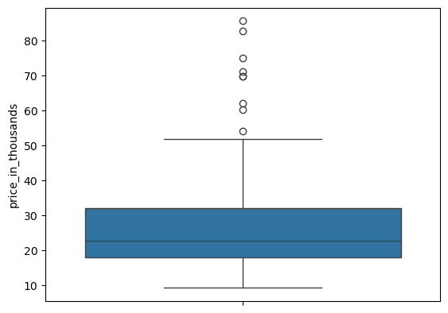

```python
sns.boxplot(df['price_in_thousands'])
```

```python
# calculating iqr
q1= df['price_in_thousands'].quantile(0.25)
q3 = df['price_in_thousands'].quantile(0.75)
IQR = q3-q1
```

```python
# calculating ul and li
li = q1 - 1.5*IQR
ul = q3 + 1.5* IQR
ul
```

```
np.float64(52.8425)
```

```python
# extracting outliers data
df[(df['price_in_thousands']>ul)|(df['price_in_thousands']<li)]
```

|  | manufacturer | model | sales_in_thousands | __year_resale_value | vehicle_type | price_in_thousands | engine_size | horsepower | wheelbase | width | length | curb_weight | fuel_capacity | fuel_efficiency | latest_launch | power_perf_factor |
| --- | --- | --- | --- | --- | --- | --- | --- | --- | --- | --- | --- | --- | --- | --- | --- | --- |
| 6 | Audi | A8 | 1.380 | 39.000 | Passenger | 62.000 | 4.2 | 310.0 | 113.0 | 74.0 | 198.2 | 3.902 | 23.7 | 21.0 | 2/27/2012 | 134.656858 |
| 39 | Dodge | Viper | 0.916 | 58.470 | Passenger | 69.725 | 8.0 | 450.0 | 96.2 | 75.7 | 176.7 | 3.375 | 19.0 | 16.0 | 8/7/2011 | 188.144323 |
| 73 | Lexus | LS400 | 6.375 | 40.375 | Passenger | 54.005 | 4.0 | 290.0 | 112.2 | 72.0 | 196.7 | 3.890 | 22.5 | 22.0 | 3/29/2012 | 124.446716 |
| 74 | Lexus | LX470 | 9.126 | NaN | Car | 60.105 | 4.7 | 230.0 | 112.2 | 76.4 | 192.5 | 5.401 | 25.4 | 15.0 | 10/30/2012 | 105.760458 |
| 94 | Mercedes-B | S-Class | 16.774 | 50.375 | Passenger | 69.700 | 4.3 | 275.0 | 121.5 | 73.1 | 203.1 | 4.133 | 23.2 | 21.0 | 6/13/2011 | 125.273876 |
| 95 | Mercedes-B | SL-Class | 3.311 | 58.600 | Passenger | 82.600 | 5.0 | 302.0 | 99.0 | 71.3 | 177.1 | 4.125 | 21.1 | 20.0 | 3/17/2011 | 139.982294 |
| 99 | Mercedes-B | CL500 | 0.954 | NaN | Passenger | 85.500 | 5.0 | 302.0 | 113.6 | 73.1 | 196.6 | 4.115 | 23.2 | 20.0 | 4/11/2011 | 141.100985 |
| 125 | Porsche | Carrera Coupe | 1.280 | 60.625 | Passenger | 71.020 | 3.4 | 300.0 | 92.6 | 69.5 | 174.5 | 3.032 | 17.0 | 21.0 | 12/21/2012 | 134.390975 |
| 126 | Porsche | Carrera Cabrio | 1.866 | 67.550 | Passenger | 74.970 | 3.4 | 300.0 | 92.6 | 69.5 | 174.5 | 3.075 | 17.0 | 23.0 | 7/11/2011 | 135.914710 |

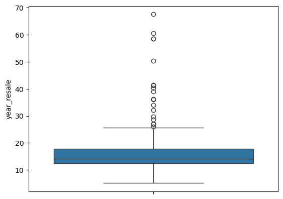

```python
sns.boxplot(df['year_resale'])
```

```python
## calculating iqr
Q_1= df['year_resale'].quantile(0.25)
Q_3= df['year_resale'].quantile(0.75)
Iqr = Q_3-Q_1
```

```python
## calculating upper limit
l_i = Q_1- 1.5*Iqr
u_l = Q_3 + 1.5*Iqr
u_l
```

```
np.float64(25.939999999999998)
```

```python
# extracting outliers
df[(df['year_resale']>u_l)& (df['year_resale'])]
```

[output not shown]

```python
# extrating null values in year_resale_value_column
df[df['year_resale'].isnull()]
```

[output not shown]

```python
# Extracting price In thousands null record
df[df['price_in_thousands'].isnull()]
```

|  | manufacturer | model | sales_in_thousands | year_resale | vehicle_type | price_in_thousands | engine_size | horsepower | wheelbase | width | length | curb_weight | fuel_capacity | fuel_efficiency | latest_launch | power_perf_factor |
| --- | --- | --- | --- | --- | --- | --- | --- | --- | --- | --- | --- | --- | --- | --- | --- | --- |

```python
# extracting engine size null record
df[df['engine_size'].isnull()]
```

|  | manufacturer | model | sales_in_thousands | year_resale | vehicle_type | price_in_thousands | engine_size | horsepower | wheelbase | width | length | curb_weight | fuel_capacity | fuel_efficiency | latest_launch | power_perf_factor |
| --- | --- | --- | --- | --- | --- | --- | --- | --- | --- | --- | --- | --- | --- | --- | --- | --- |

```python
# extracting column horsepowr  null value
df[df['horsepower'].isnull()]
```

|  | manufacturer | model | sales_in_thousands | year_resale | vehicle_type | price_in_thousands | engine_size | horsepower | wheelbase | width | length | curb_weight | fuel_capacity | fuel_efficiency | latest_launch | power_perf_factor |
| --- | --- | --- | --- | --- | --- | --- | --- | --- | --- | --- | --- | --- | --- | --- | --- | --- |

```python
# extracting wheelbase null record
df[df['wheelbase'].isnull()]
```

|  | manufacturer | model | sales_in_thousands | year_resale | vehicle_type | price_in_thousands | engine_size | horsepower | wheelbase | width | length | curb_weight | fuel_capacity | fuel_efficiency | latest_launch | power_perf_factor |
| --- | --- | --- | --- | --- | --- | --- | --- | --- | --- | --- | --- | --- | --- | --- | --- | --- |

```python
df[df['width'].isnull()]
```

|  | manufacturer | model | sales_in_thousands | year_resale | vehicle_type | price_in_thousands | engine_size | horsepower | wheelbase | width | length | curb_weight | fuel_capacity | fuel_efficiency | latest_launch | power_perf_factor |
| --- | --- | --- | --- | --- | --- | --- | --- | --- | --- | --- | --- | --- | --- | --- | --- | --- |

```python
df[df['curb_weight'].isnull()]
```

|  | manufacturer | model | sales_in_thousands | year_resale | vehicle_type | price_in_thousands | engine_size | horsepower | wheelbase | width | length | curb_weight | fuel_capacity | fuel_efficiency | latest_launch | power_perf_factor |
| --- | --- | --- | --- | --- | --- | --- | --- | --- | --- | --- | --- | --- | --- | --- | --- | --- |

```python
df[df['fuel_efficiency'].isnull()]
```

|  | manufacturer | model | sales_in_thousands | year_resale | vehicle_type | price_in_thousands | engine_size | horsepower | wheelbase | width | length | curb_weight | fuel_capacity | fuel_efficiency | latest_launch | power_perf_factor |
| --- | --- | --- | --- | --- | --- | --- | --- | --- | --- | --- | --- | --- | --- | --- | --- | --- |

```python
df[df['power_perf_factor'].isnull()]
```

|  | manufacturer | model | sales_in_thousands | year_resale | vehicle_type | price_in_thousands | engine_size | horsepower | wheelbase | width | length | curb_weight | fuel_capacity | fuel_efficiency | latest_launch | power_perf_factor |
| --- | --- | --- | --- | --- | --- | --- | --- | --- | --- | --- | --- | --- | --- | --- | --- | --- |

```python
df.duplicated().sum()
```

```
np.int64(0)
```

## Data preprosing or Data cleaning

```python
df.isnull().sum()
```

[output not shown]

```python
df.rename(columns = {'__year_resale_value':'year_resale'}, inplace =True)
# rename the column that wrong text formate
```

```python
df['year_resale'].describe()
```

[output not shown]

```python
# fill null values of year_resale column
df.fillna({'year_resale': df['year_resale'].median()}, inplace=True)
```

```python
## Acura car price in thousand null value

acura_median = df.loc[df['manufacturer'] == 'Acura', 'price_in_thousands'].median()

df.loc[df['manufacturer'] == 'Acura', 'price_in_thousands'] = (
    df.loc[df['manufacturer'] == 'Acura', 'price_in_thousands'].fillna(acura_median)
)
# fill null values of price in thousand and  manufacturer = acura
```

```python
df[df['curb_weight'].isnull()]
```

[output not shown]

```python
# fill curb weight null value with its original data
curb_weight_median = df.loc[df['manufacturer']=='Cadillac','curb_weight'].median()
df.loc[df['manufacturer']=='Cadillac','curb_weight']=(
    df.loc[df['manufacturer']=='Cadillac','curb_weight'].fillna(curb_weight_median))
```

```python
# extracting null values of fule efficiency
df[df['fuel_efficiency'].isnull()]
```

[output not shown]

```python
# filling fule efficiency null value with its original data median

Dodge_median = df.loc[df['manufacturer']== 'Dodge', 'fuel_efficiency'].median()
df.loc[df['manufacturer']=='Dodge','fuel_efficiency']=(
    df.loc[df['manufacturer']=='Dodge','fuel_efficiency'].fillna(Dodge_median))

oldsmobile_median = df.loc[df['manufacturer']== 'Oldsmobile', 'fuel_efficiency'].median()
df.loc[df['manufacturer']=='Oldsmobile','fuel_efficiency']=(
    df.loc[df['manufacturer']=='Oldsmobile','fuel_efficiency'].fillna(oldsmobile_median))
```

```python
# extracting null values of power_perf_factor column
df[df['power_perf_factor'].isnull()]
```

[output not shown]

```python
# filling null value of ppf of with its original data

Acura__m = df.loc[df['manufacturer']== 'Acura', 'power_perf_factor'].median()
df.loc[df['manufacturer']=='Acura','power_perf_factor']=(
    df.loc[df['manufacturer']=='Acura','power_perf_factor'].fillna(Acura__m))
```

# Data analysis

```python
# see corelation
numeric_df = df.select_dtypes(include=['float64', 'int64'])  # select numeric column
corr_matrix = numeric_df.corr() # create corr matrix
print(corr_matrix)
```

[output not shown]

```python
plt.figure(figsize = (15,10))
sns.heatmap(corr_matrix,annot =True)
plt.show()
```

[output not shown]

### good correlation

- power peif factor == horcepower and price in thousands and year resale
- fule capacity is good correlation with curb weight
- curb size is good correlation with engie size , width, fuel capacity
- length has good correlation with wheelbase and width
- Horcepower has good correlation with price in thousand and engine size and power_ perf factor
- engin size with powe perf factor
- price in thousand correlated with year resale value , horspower , ppf

```python
sns.scatterplot(x = df['price_in_thousands'], y = df['year_resale'], color = 'red')
plt.title('Correlation of price in thousand and yearly resae value ')
plt.show()
```

[output not shown]

## Observation

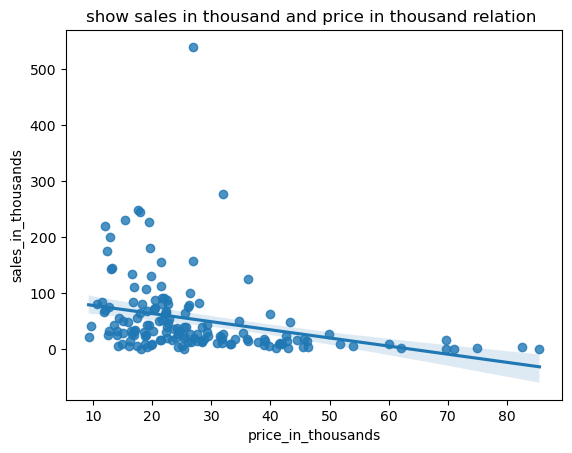

```python
sns.regplot(x='price_in_thousands', y='sales_in_thousands', data=df)
plt.title('show sales in thousand and price in thousand relation ')
plt.show()
```

## Observation

- lower price higher sales
- higher price low sales
- price increases --> sales decreases
- cheaper cars ( arround 10 - 25 thousand ) have higher sales.
- expencive car (50-80 ) thousand have lower sales
- When price goes up sales goes down

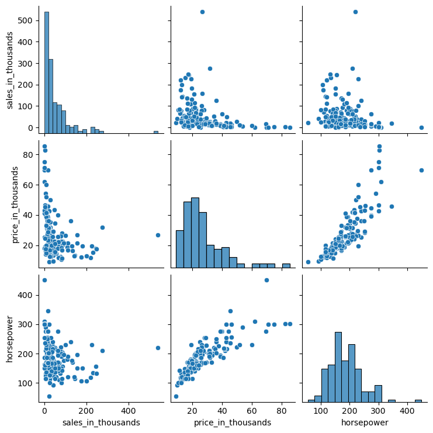

```python
sns.pairplot(df[['sales_in_thousands',
                 'price_in_thousands',
                 'horsepower',
                 ]])
plt.show()
```

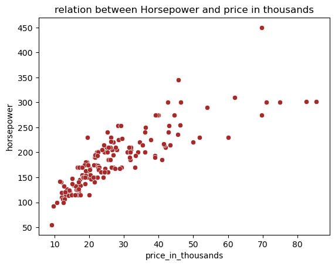

```python
sns.scatterplot(x = 'price_in_thousands' , y ='horsepower', data = df, color = 'brown')
plt.title("relation between Horsepower and price in thousands")
plt.show()
```

## Observation

- Horsepower increases --> Price in thousands increases
- Horsepower decreses --> price in thowsand decreases

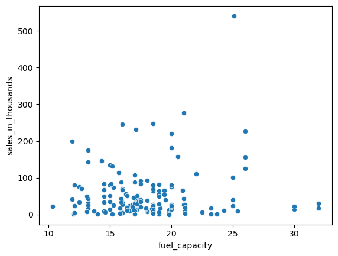

```python
sns.scatterplot(x = df['fuel_capacity'], y = df['sales_in_thousands'])
plt.show()
```

## Observation

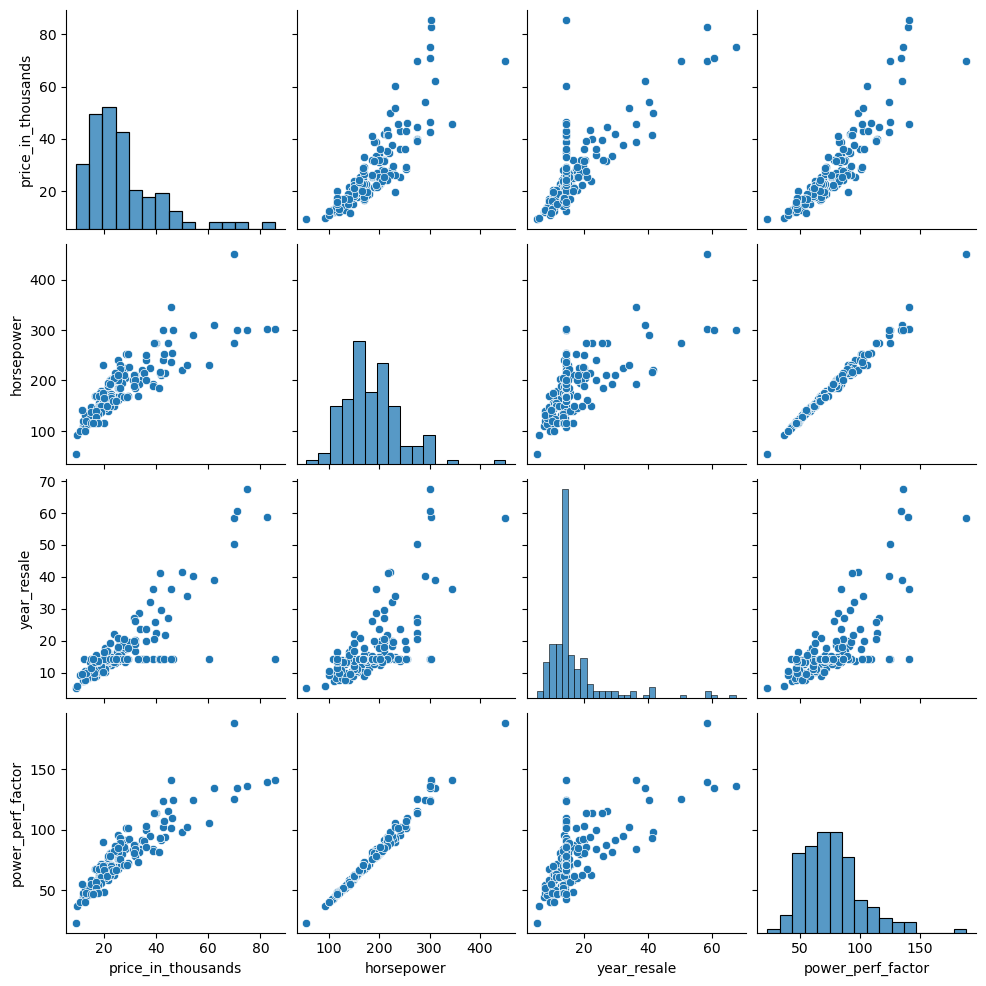

```python
sns.pairplot(df[['price_in_thousands',
              'horsepower',
              'year_resale',
              'power_perf_factor']] )
plt.show()
```

## Ovservation

- Higher year_resale values are associated with higher car prices.
- As power_perf_factor increases, the price increases sharply.
- Cars with higher horsepower almost always have a higher performance factor.
- Cars with more horsepower tend to maintain better resale value, but the trend is not very strong.
- Cars with higher performance factors slightly maintain better resale values.

```python
df.groupby('model')['sales_in_thousands'].max().sort_values(ascending=False)
```

```
model
F-Series         540.561
Explorer         276.747
Camry            247.994
Taurus           245.815
Accord           230.902
                  ...
Carrera Coupe      1.280
Cutlass            1.112
CL500              0.954
Viper              0.916
3000GT             0.110
Name: sales_in_thousands, Length: 155, dtype: float64
```

## Ovservation

- f series model sales is high
- mediam sales model = of Explorer, camry, Taurus, Sccord This cars is midium sales
- low sales model = Carrera Coupe,Cutlass ,CL500, Viper

```python
# which manufacturer produce most expensive cars
most_expensive = df.groupby('manufacturer')['price_in_thousands'].mean() \
                   .sort_values(ascending=False)

print(most_expensive.head())
```

```
manufacturer
Porsche       62.473333
Mercedes-B    52.916667
Lexus         44.055000
Jaguar        42.800000
Lincoln       41.690000
Name: price_in_thousands, dtype: float64
```

## Observation

- Porsche , mercedes - b, lexus, jaguar, lincoln this manufacturer produce most expensive cars

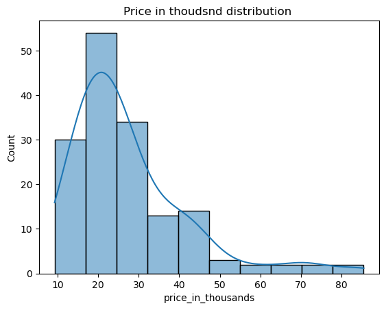

```python
# How price in thousand distributed
sns.histplot(df['price_in_thousands'], bins = 10, kde = True )
plt.title('Price in thoudsnd distribution ')
plt.show()
```

## Observation

- Most of the car price between (10- 40 ) thousand
- expensive car price between (50 - 80 ) thousands

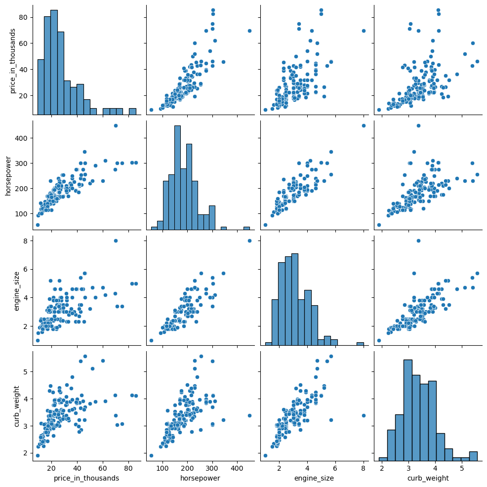

```python
sns.pairplot(df[['price_in_thousands',
                 'horsepower','engine_size',
                 'curb_weight']])
plt.show()
```

## observation

```python
df.groupby('year_resale')['sales_in_thousands'].max().sort_values(ascending = False)
```

```
year_resale
15.075    540.561
16.640    276.747
13.245    247.994
10.055    245.815
13.210    230.902
           ...
39.000      1.380
60.625      1.280
11.240      1.112
58.470      0.916
20.940      0.110
Name: sales_in_thousands, Length: 116, dtype: float64
```

## Observation

- that car year_resale value (10 - 16 ) that sales is high

```python
df
```

|  | manufacturer | model | sales_in_thousands | year_resale | vehicle_type | price_in_thousands | engine_size | horsepower | wheelbase | width | length | curb_weight | fuel_capacity | fuel_efficiency | latest_launch | power_perf_factor |
| --- | --- | --- | --- | --- | --- | --- | --- | --- | --- | --- | --- | --- | --- | --- | --- | --- |
| 0 | Acura | Integra | 16.919 | 16.360 | Passenger | 21.50 | 1.8 | 140.0 | 101.2 | 67.3 | 172.4 | 2.639 | 13.2 | 28.0 | 2/2/2012 | 58.280150 |
| 1 | Acura | TL | 39.384 | 19.875 | Passenger | 28.40 | 3.2 | 225.0 | 108.1 | 70.3 | 192.9 | 3.517 | 17.2 | 25.0 | 6/3/2011 | 91.370778 |
| 2 | Acura | CL | 14.114 | 18.225 | Passenger | 28.40 | 3.2 | 225.0 | 106.9 | 70.6 | 192.0 | 3.470 | 17.2 | 26.0 | 1/4/2012 | 91.370778 |
| 3 | Acura | RL | 8.588 | 29.725 | Passenger | 42.00 | 3.5 | 210.0 | 114.6 | 71.4 | 196.6 | 3.850 | 18.0 | 22.0 | 3/10/2011 | 91.389779 |
| 4 | Audi | A4 | 20.397 | 22.255 | Passenger | 23.99 | 1.8 | 150.0 | 102.6 | 68.2 | 178.0 | 2.998 | 16.4 | 27.0 | 10/8/2011 | 62.777639 |
| ... | ... | ... | ... | ... | ... | ... | ... | ... | ... | ... | ... | ... | ... | ... | ... | ... |
| 152 | Volvo | V40 | 3.545 | 14.180 | Passenger | 24.40 | 1.9 | 160.0 | 100.5 | 67.6 | 176.6 | 3.042 | 15.8 | 25.0 | 9/21/2011 | 66.498812 |
| 153 | Volvo | S70 | 15.245 | 14.180 | Passenger | 27.50 | 2.4 | 168.0 | 104.9 | 69.3 | 185.9 | 3.208 | 17.9 | 25.0 | 11/24/2012 | 70.654495 |
| 154 | Volvo | V70 | 17.531 | 14.180 | Passenger | 28.80 | 2.4 | 168.0 | 104.9 | 69.3 | 186.2 | 3.259 | 17.9 | 25.0 | 6/25/2011 | 71.155978 |
| 155 | Volvo | C70 | 3.493 | 14.180 | Passenger | 45.50 | 2.3 | 236.0 | 104.9 | 71.5 | 185.7 | 3.601 | 18.5 | 23.0 | 4/26/2011 | 101.623357 |
| 156 | Volvo | S80 | 18.969 | 14.180 | Passenger | 36.00 | 2.9 | 201.0 | 109.9 | 72.1 | 189.8 | 3.600 | 21.1 | 24.0 | 11/14/2011 | 85.735655 |

156 rows × 16 columns

```python
# vechile type affect on price
df.groupby('vehicle_type')['price_in_thousands'].mean().sort_values(ascending = False)
```

```
vehicle_type
Passenger    27.768690
Car          26.319975
Name: price_in_thousands, dtype: float64
```

## Observation

- do not effect vechilee type on price

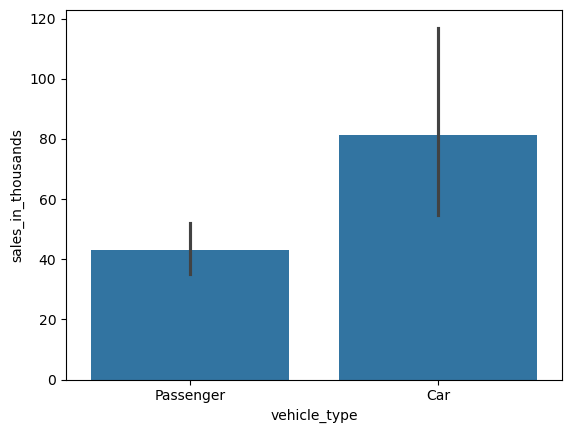

```python
# which type of vehicle is high sales
sns.barplot(x = df['vehicle_type'], y = df['sales_in_thousands'])

plt.show()
```

## observation

- car are high sales comperetivly passenger

```python
# Top 5 manufacturer that higest sales
df.groupby('manufacturer')['sales_in_thousands'].max().sort_values(ascending = False).head()
```

```
manufacturer
Ford      540.561
Toyota    247.994
Honda     230.902
Dodge     227.061
Jeep      157.040
Name: sales_in_thousands, dtype: float64
```

```python
# which car model sale hightest car
df.groupby('model')['sales_in_thousands'].max().sort_values(ascending= False)
```

```
model
F-Series         540.561
Explorer         276.747
Camry            247.994
Taurus           245.815
Accord           230.902
                  ...
Carrera Coupe      1.280
Cutlass            1.112
CL500              0.954
Viper              0.916
3000GT             0.110
Name: sales_in_thousands, Length: 155, dtype: float64
```

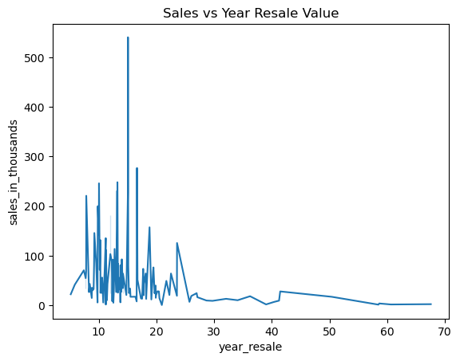

```python
sns.lineplot(data=df, x='year_resale', y='sales_in_thousands')
plt.title("Sales vs Year Resale Value")
plt.show()
```

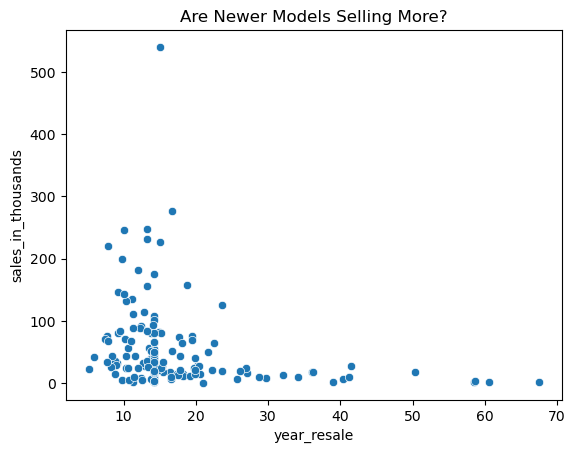

```python
sns.scatterplot(data=df, x='year_resale', y='sales_in_thousands')
plt.title("Are Newer Models Selling More?")
plt.show()
```

## observation

```python
# Does higher fuel_efficiency affect sales positively or negatively?
df.groupby('fuel_efficiency')['sales_in_thousands'] \
  .max() \
  .sort_values(ascending=False)
```

```
fuel_efficiency
18.0    540.561
19.0    276.747
27.0    247.994
24.0    245.815
17.0    227.061
23.0    220.650
32.0    199.685
30.0    175.670
21.0    155.787
33.0    142.535
25.0    135.126
16.0    125.338
26.0     83.721
20.0     80.556
29.0     76.034
22.0     65.119
28.0     49.989
31.0     41.184
15.0     22.925
45.0     21.855
Name: sales_in_thousands, dtype: float64
```

## fule efficiency is not affect on sales positively

```python
# which model has higher power_preif factor
pd.crosstab('model')['power_preif factor'].max().sort_values(ascending = False)
```

[output not shown]